# DATA612 Project: Gender Disparities in American Labor Markets

An Analysis of Labor Force Participation and Earnings Gaps Over Time

Alyssa Langmeyer

2025-04-28

## 1 Datasets

### 1.1 Civilian Labor Force by Sex - U.S. Department of Labor

### 1.2 Labor force participation rate of women by age - U.S. Department of Labor

### 1.3 Women’s earnings by race and ethnicity as a percentage of WNH men’s earnings, 1987+ - U.S. Department of Labor

### 1.4 Combining the Datasets

## 2 Data Explanation

### 2.1 Tibble Overview

First 10 Rows of Combined Labor Market Data

| year | female_labor_count | male_labor_count | labor_force_pct_female | female_participation_25_54 | earnings_pct_white | earnings_pct_black | earnings_pct_asian | earnings_pct_hispanic |
| --- | --- | --- | --- | --- | --- | --- | --- | --- |
| 1948 | 17335 | 43286 | 0.2859570 | 35.0 | NA | NA | NA | NA |
| 1949 | 17788 | 43498 | 0.2902457 | 35.7 | NA | NA | NA | NA |
| 1950 | 18389 | 43819 | 0.2956051 | 36.8 | NA | NA | NA | NA |
| 1951 | 19016 | 43001 | 0.3066256 | 38.1 | NA | NA | NA | NA |
| 1952 | 19269 | 42869 | 0.3101001 | 38.5 | NA | NA | NA | NA |
| 1953 | 19382 | 43633 | 0.3075776 | 38.3 | NA | NA | NA | NA |
| 1954 | 19678 | 43965 | 0.3091935 | 38.7 | NA | NA | NA | NA |
| 1955 | 20548 | 44475 | 0.3160113 | 39.8 | NA | NA | NA | NA |
| 1956 | 21461 | 45091 | 0.3224696 | 41.0 | NA | NA | NA | NA |
| 1957 | 21732 | 45197 | 0.3247023 | 41.5 | NA | NA | NA | NA |

### 2.2 Quantitative Variables

| Variable | Description | Unit | Years_Available |
| --- | --- | --- | --- |
| year | Year of observation | Calendar year | 1948-present |
| female_labor_count | Number of women in civilian labor force | Thousands | 1948-present |
| male_labor_count | Number of men in civilian labor force | Thousands | 1948-present |
| labor_force_pct_female | Women’s share of total labor force | Percentage | 1948-present |
| labor_force_pct_male | Men’s share of total labor force | Percentage | 1948-present |
| female_participation_16plus | Women’s labor force participation (16+) | Percentage | 1948-present |
| female_participation_25_54 | Women’s labor force participation (25-54) | Percentage | 1948-present |
| female_participation_55_64 | Women’s labor force participation (55-64) | Percentage | 1948-present |
| earnings_pct_white | White women’s earnings as % of white men’s | Percentage | 1987-present |
| earnings_pct_black | Black women’s earnings as % of white men’s | Percentage | 1987-present |
| earnings_pct_asian | Asian women’s earnings as % of white men’s | Percentage | 1988-present |
| earnings_pct_hispanic | Hispanic women’s earnings as % of white men’s | Percentage | 1987-present |

### 2.3 Categorical Variables

| Variable | Description | Possible_Values |
| --- | --- | --- |
| has_labor_force_data | Indicates if labor force counts are available | TRUE/FALSE |
| has_participation_data | Indicates if participation rates are available | TRUE/FALSE |
| has_earnings_data | Indicates if earnings data are available | TRUE/FALSE |

### 2.4 Relevance of Data

The datasets from the U.S. Department of Labor provide a comprehensive view of gender disparities in American labor markets from 1948-2025. This period captures: - Post-WWII economic expansion - Feminist movement impacts (1960s-70s) - Globalization effects (1990s+) - Recent pandemic labor market disruptions

The combined dataset is particularly valuable because it links: 1. Macro-level labor force composition 2. Age-specific participation patterns 3. Intersectional earnings disparities by race/ethnicity

## 3 Data Visualization and Analysis

### 3.1 Share of Civilian Labor Force by Gender (1948-2025)

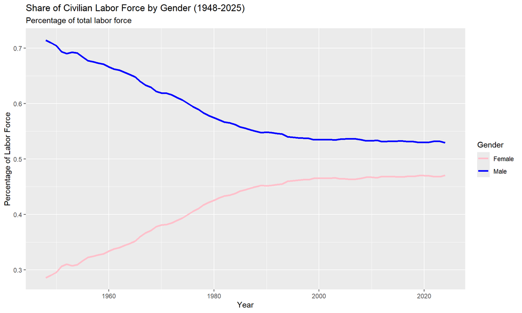

This graph illustrates the fundamental shift in the gender composition of the paid U.S. labor force since the end of the World War II. Since 1948, the share of women participating in the paid labor market has grown from 28.6% to 47.1% in 2023. The share of men in the workforce has declined corresponding from 71.4% t0 52.9%. This helps illustrate the drastic change in traditional gender roles in the workplace over the last eighty years as women have finally began to gain financial autonomy and independence through the paid labor market.

### 3.2 Labor Force Participation Rates by Age Group (Women)

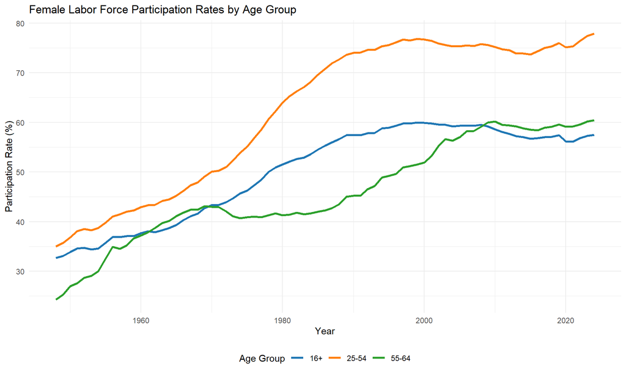

This line graph of the differences in labor force participation rates by age group over time highlights key differences in labor force participation patterns across different stages of life. Prime-age women consistently maintain the highest participation rates, but there has been a dramatic increase in participation among women ages 55-64 (the cohort nearest retirement), which more than doubled from 24.3% to 60.4%, suggesting changing social norms and delaying of retirements.

### 3.3 Women’s Earnings Gap by Race/Ethnicity (Interactive)

[interactive chart not shown]

### 3.4 New - Slope Chart

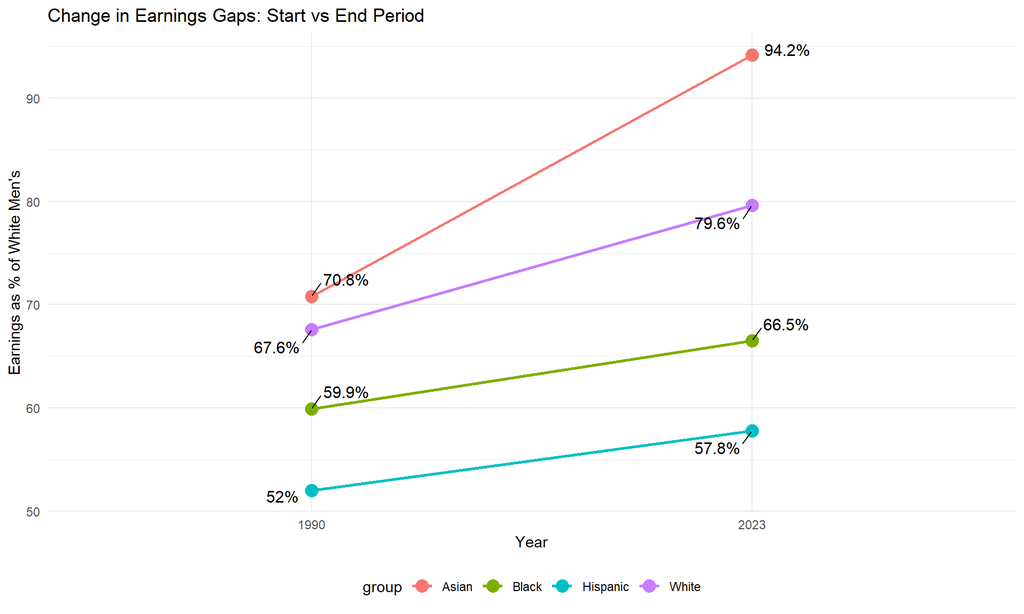

### 3.5 Side-by-Side Comparison: Participation vs Earnings

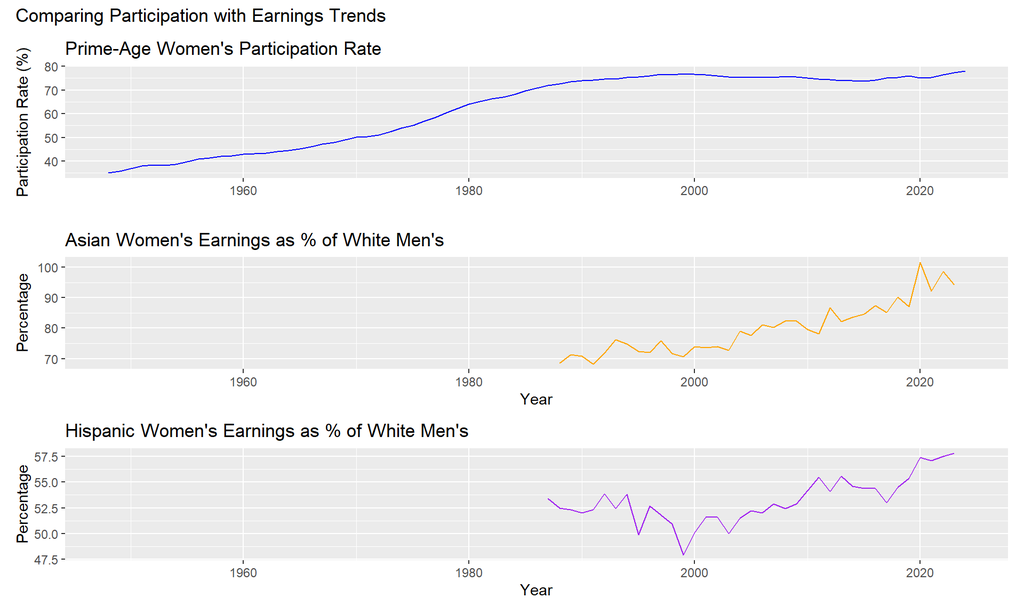

### 3.6 Exploratory Data Analysis

| Variable | Mean | SD | Minimum | Maximum | Observations |
| --- | --- | --- | --- | --- | --- |
| Female Share of Labor Force | 0.41 | 0.06 | 0.29 | 0.47 | 77 |
| Male Share of Labor Force | 0.59 | 0.06 | 0.53 | 0.71 | 77 |
| White Women’s Earnings (% of WNH Men) | 73.20 | 4.65 | 63.50 | 80.00 | 37 |
| Black Women’s Earnings (% of WNH Men) | 61.88 | 2.44 | 58.00 | 69.10 | 37 |
| Asian Women’s Earnings (% of WNH Men) | 79.80 | 8.46 | 68.20 | 101.60 | 36 |
| Hispanic Women’s Earnings (% of WNH Men) | 53.20 | 2.23 | 47.90 | 57.80 | 37 |
| Women’s Participation (16+) | 50.17 | 9.35 | 32.70 | 60.00 | 77 |
| Women’s Participation (25-54) | 62.37 | 14.87 | 35.00 | 77.90 | 77 |
| Women’s Participation (55-64) | 46.11 | 10.10 | 24.30 | 60.40 | 77 |
| has_participation_data | NaN | NA | Inf | -Inf | 77 |
| has_earnings_data | NaN | NA | Inf | -Inf | 77 |

### 3.7 Regression Analysis

```
##
## Call:
## lm(formula = earnings_pct_white ~ female_participation_25_54 +
##     year, data = combined_labor_data)
##
## Residuals:
##     Min      1Q  Median      3Q     Max
## -3.7184 -1.0278  0.1115  0.7958  2.3129
##
## Coefficients:
##                              Estimate Std. Error t value Pr(>|t|)
## (Intercept)                -748.37295   44.15832 -16.947   <2e-16 ***
## female_participation_25_54    0.41676    0.21234   1.963   0.0579 .
## year                          0.39414    0.02304  17.108   <2e-16 ***
## ---
## Signif. codes:  0 '***' 0.001 '**' 0.01 '*' 0.05 '.' 0.1 ' ' 1
##
## Residual standard error: 1.429 on 34 degrees of freedom
##   (40 observations deleted due to missingness)
## Multiple R-squared:  0.9108, Adjusted R-squared:  0.9056
## F-statistic: 173.6 on 2 and 34 DF,  p-value: < 2.2e-16
```

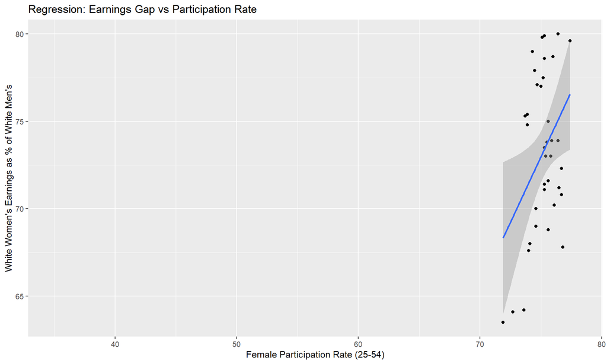

- The model explains 91.1% of the variance (R² = 0.9108), indicating a very strong relationship between the predictors (participation rate and year) and the earnings gap.

- Female Labor Force Participation has a marginal positive effect
- Coefficient for Participation: +0.417 (p = 0.0579)
  - A 1% increase in prime-age women’s labor force participation is associated with a ~0.42 percentage point increase in relative earnings, controlling for time.
  - The effect is marginally significant (p ≈ 0.06), suggesting that higher participation may modestly narrow the gap, but other factors (e.g., occupational segregation, wage transparency) likely play larger roles.

## 4 Sources

U.S. Department of Labor, Women’s Bureau. (2025). *Civilian labor force by sex, 1948-2025* [Data set]. Retrieved from https://www.dol.gov/agencies/wb/data/lfp/civilianlfbysex

U.S. Department of Labor, Women’s Bureau. (2025). *Labor force participation rate of women by age, 1948-2025* [Data set]. Retrieved from https://www.dol.gov/agencies/wb/data/lfp/women-by-age

U.S. Department of Labor, Women’s Bureau. (2025). *Women’s earnings by race and ethnicity as a percentage of White non-Hispanic men’s earnings, 1987-2025* [Data set]. Retrieved from https://www.dol.gov/agencies/wb/data/earnings/race-percentage-white-hispanic